# Class Activity, April 4

This class activity will give you some practice with some of the material for Exam 2.

## Scenario

How does stress impact animals’ oxygen consumption? To investigate this question, biologists exposed 100 crabs to either 7.5 minutes of loud ship noise, or 7.5 minutes of normal ocean noise, and recorded their oxygen consumption. The data contain the following variables.

- `Mass`: crab mass (g)
- `Oxygen`: rate of oxygen consumption (micromoles per hour)
- `Noise`: type of noise (either `ocean` or `ship`)

The researchers are interested in the relationship between mass and oxygen consumption, and the impact of noise on this relationship. They make the following scatterplot:

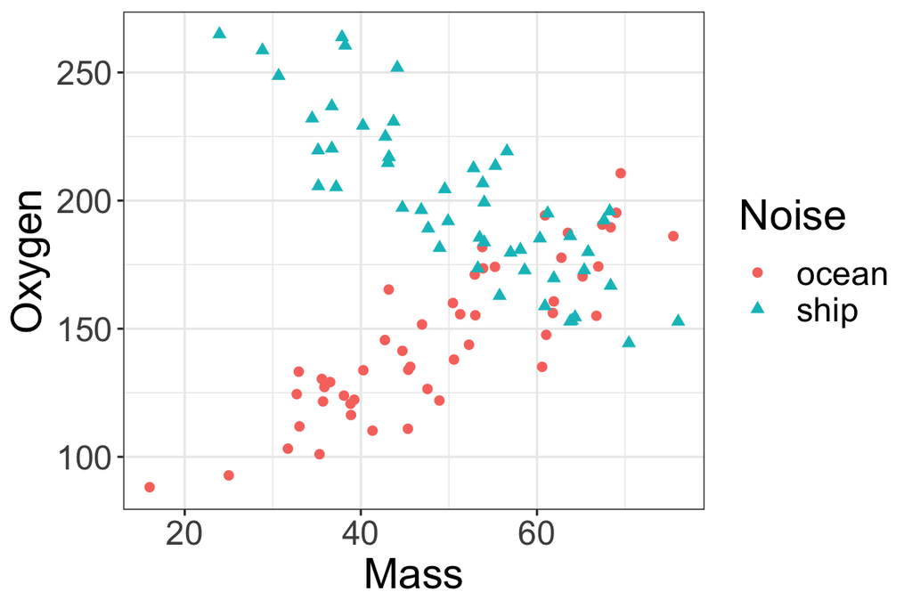

They consider three different models for this relationship ($\text{IsShip}$ is an indicator variable which is 1 for ship noise, and 0 for ocean noise):

$(1) \hspace{1cm} \text{oxygen} = \beta_0 + \beta_1 \text{mass} + \varepsilon$

$(2) \hspace{1cm} \text{oxygen} = \beta_0 + \beta_1 \text{IsShip} + \beta_2 \text{mass} + \varepsilon$

$(3) \hspace{1cm} \text{oxygen} = \beta_0 + \beta_1 \text{IsShip} + \beta_2 \text{mass} + \beta_3 \text{IsShip} \cdot \text{mass} + \varepsilon$

The estimated equations for these models are

$(1) \hspace{1cm} \widehat{\text{oxygen}} = 161.29 + 0.23 \ \text{mass}$

$(2) \hspace{1cm} \widehat{\text{oxygen}} = 143.72 + 53.68 \ \text{IsShip} + 0.05 \ \text{mass}$

$(3) \hspace{1cm} \widehat{\text{oxygen}} = 52.06 + 257.38 \ \text{IsShip} + 1.92 \ \text{mass} - 4.05 \ \text{IsShip} \cdot \text{mass}$

## Questions

1. Based on the scatterplot, which of these three models do you think is most appropriate? Explain your reasoning.
2. For each of the *other* two models, draw a scatterplot that would encourage you to choose that model, instead of the model selected in Question 1.
3. Using the estimated equation for the model you chose in question 1, what is the predicted rate of oxygen consumption for a 40g crab exposed to ocean noise? What about for a 40g crab exposed to ship noise?
4. What is the estimated change in oxygen consumption associated with a 1g increase in Mass, for crabs exposed to ship noise?
5. The researchers want to test whether there is any relationship between ship noise and oxygen consumption, after accounting for mass. Write down a null and alternative hypothesis for this test, in terms of one or more parameters from the model.
6. What test can the researchers use to test their hypotheses? Explain your reasoning, and provide the degrees of freedom.
7. Below are the ANOVA tables for the three fitted models. Use these tables to calculate a test statistic for the hypotheses in Question 5.

```r
m1 <- lm(Oxygen ~ Mass, data = crabs)
anova(m1)
```

```
## Analysis of Variance Table
##
## Response: Oxygen
##           Df Sum Sq Mean Sq F value Pr(>F)
## Mass       1    895  894.52  0.5351 0.4662
## Residuals 98 163817 1671.61
```

```r
m2 <- lm(Oxygen ~ Mass + Noise, data = crabs)
anova(m2)
```

```
## Analysis of Variance Table
##
## Response: Oxygen
##           Df Sum Sq Mean Sq F value   Pr(>F)
## Mass       1    895     895  0.9398   0.3347
## Noise      1  71489   71489 75.1070 1.01e-13 ***
## Residuals 97  92328     952
## ---
## Signif. codes:  0 '***' 0.001 '**' 0.01 '*' 0.05 '.' 0.1 ' ' 1
```

```r
m3 <- lm(Oxygen ~ Mass*Noise, data = crabs)
anova(m3)
```

```
## Analysis of Variance Table
##
## Response: Oxygen
##            Df Sum Sq Mean Sq  F value  Pr(>F)
## Mass        1    895     895   3.2786 0.07332 .
## Noise       1  71489   71489 262.0215 < 2e-16 ***
## Mass:Noise  1  66135   66135 242.3981 < 2e-16 ***
## Residuals  96  26192     273
## ---
## Signif. codes:  0 '***' 0.001 '**' 0.01 '*' 0.05 '.' 0.1 ' ' 1
```